# Assessment 0

## Introduction

1. **data source** MACCDC2012 – Generated with Bro from the 2012 dataset,a nice dataset that has everything from scanning/recon through explotation as well as some c99 shell traffic. Roughly 22694356 total connections.

The network data is divided into different categories, I chose four of them, including dhcp, ftp, smtp, and tunnel, and I observed and compared them, from the perspective of count, timestamp, Originating/Responding endpoint’s TCP/UDP port, and Originating/Responding endpoint’s IP address.

2. **data source** KDD Cup 1999 Data – contains a standard set of data to be audited, which includes a wide variety of intrusions simulated in a military network environment.

According to the fact that attacks fall into four main categories, including “DOS”, “R2L”, “U2R”, “probing”, I divided the network data’s result into 5 groups (also includes “normal”), and analyzed the influence of each attribute on the intrusion type.

## Activity 1.1: Read and observe the data

```r
#"D:\\dst\\data\\...." is my Data storage location.
dhcpdata<-read.csv("D:\\dst\\data\\dhcp.csv")
ftpdata<-read.csv("D:\\dst\\data\\ftp.csv")
smtpdata<-read.csv("D:\\dst\\data\\smtp.csv")
tunneldata<-read.csv("D:\\dst\\data\\tunnel.csv")
head(smtpdata)
```

```
##           ts                uid       id.orig_h id.orig_p       id.resp_h
## 1 1331902024 CtoBox4y93gvzs9sZb  192.168.202.79     44926 192.168.229.251
## 2 1331902044 CiH1mj1NuwWexXJJs7  192.168.202.79     45600 192.168.229.251
## 3 1331903554 C1UPWd4AxJntAm62il  192.168.203.45     33236  192.168.21.202
## 4 1331903556 CEyP812szkmdgAPmz1  192.168.203.45     44845  192.168.21.102
## 5 1331903559 CNt2nu23IsJHrDYXAl  192.168.203.45     58576  192.168.21.203
## 6 1331903967 CYzIJQ2jEjdAEfDB65 192.168.202.110     57127  192.168.27.102
##   id.resp_p proto     trans_depth helo mailfrom rcptto date from to in_reply_to
## 1        25     1 nmap.scanme.org                   NA   NA   NA NA          NA
## 2        25     1     example.org                   NA   NA   NA NA          NA
## 3        25     1 nmap.scanme.org                   NA   NA   NA NA          NA
## 4        25     1 nmap.scanme.org                   NA   NA   NA NA          NA
## 5        25     1 nmap.scanme.org                   NA   NA   NA NA          NA
## 6        25     1 mail.nessus.org                   NA   NA   NA NA          NA
##   subject x_originating_ip first_received second_received last_reply
```

[output cut: 20 more lines]

## Activity 1.2: Various data’s count

```r
data_count<-c(nrow(dhcpdata),nrow(ftpdata),nrow(smtpdata),nrow(tunneldata))
data_name<-c("dhcp","ftp","smtp","tunnel")

#
rbind(data_name,data_count)
```

```
##            [,1]   [,2]   [,3]   [,4]
## data_name  "dhcp" "ftp"  "smtp" "tunnel"
## data_count "1502" "5796" "194"  "280"
```

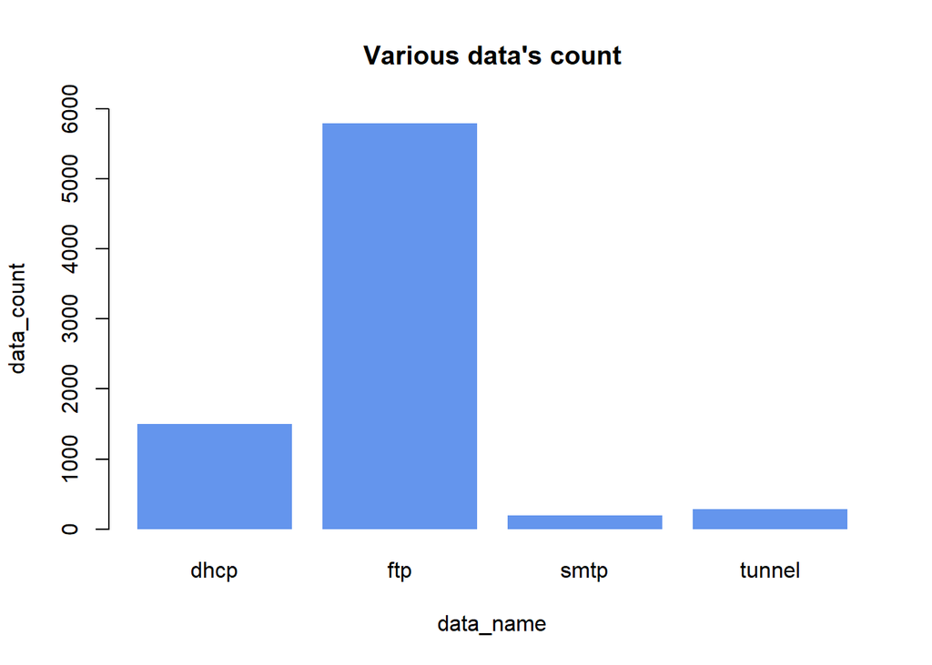

```r
#Histogram
barplot(data_count,names.arg=data_name,ylim=c(0,6000),xlab="data_name",ylab="data_count",main="Various data's count",col="#6495ED",border = NA)
```

From the above frame and histogram, we can get the count of various connections, of which ftp is the most, after all, it is one of the most common protocols in the application layer.

## Activity 1.3: Various data’s timestamp

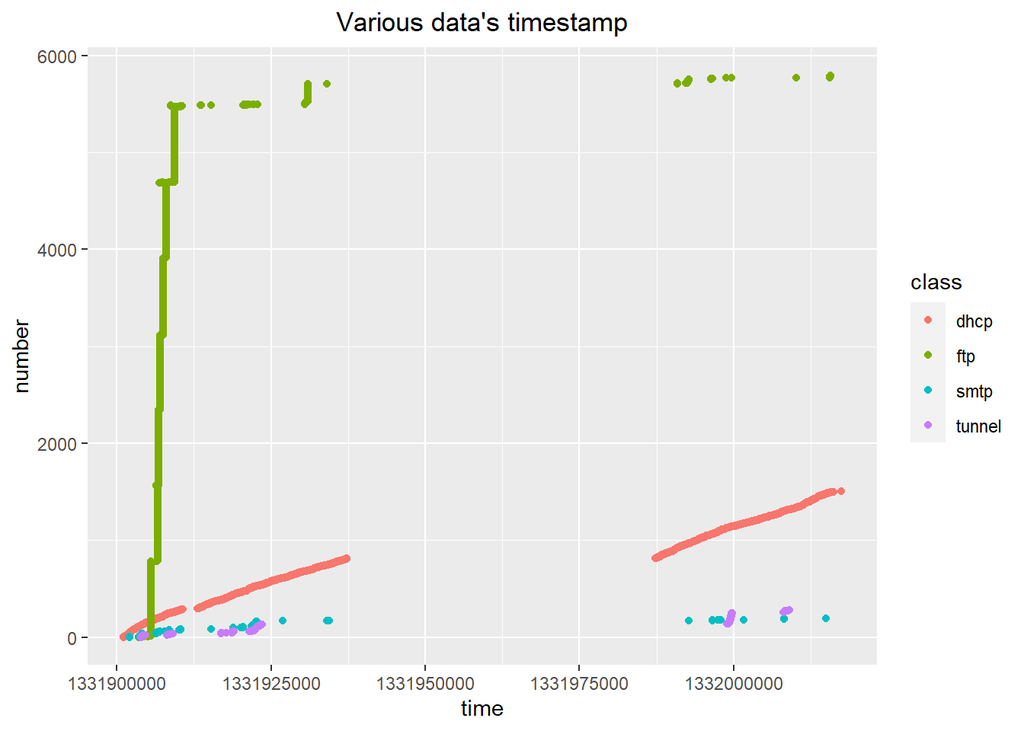

```r
library(ggplot2)
#Create data frame of dhcp's timestamp
number<-c(1:data_count[1])
time<-dhcpdata$ts
class<-rep("dhcp",data_count[1])
dhcptime<-data.frame(number,time,class)

#Create data frame of ftp's timestamp
number<-c(1:data_count[2])
time<-ftpdata$ts
class<-rep("ftp",data_count[2])
ftptime<-data.frame(number,time,class)

#Create data frame of smtp's timestamp
number<-c(1:data_count[3])
time<-smtpdata$ts
class<-rep("smtp",data_count[3])
smtptime<-data.frame(number,time,class)

#Create data frame of tunnel's timestamp
number<-c(1:data_count[4])
time<-tunneldata$ts
class<-rep("tunnel",data_count[4])
tunneltime<-data.frame(number,time,class)

#Merge the above data frame
totaltime<-rbind(dhcptime,ftptime,smtptime,tunneltime)

#Scatterplot
ggplot(totaltime,aes(x=time,y=number,colour=class)) +geom_point() +ggtitle("Various data's timestamp") +theme(plot.title=element_text(hjust = 0.5))
```

The highest point on the y-axis of each type of data also represents its count.

All connections are gathered on two time periods. There is no such four connections for a period of time, perhaps it is a network interruption or there are other connections.

Different connection timestamps have different changes, Most ftp occurs in an earlier time period, dhcp is relatively continuous and uniform, while smtp and tunnel are relatively intermittent.

## Activity 1.4: Originating endpoint’s TCP/UDP port (or ICMP code)

```r
sort(table(dhcpdata$id.orig_p), decreasing=TRUE)[1:5]
```

```
##   68 <NA> <NA> <NA> <NA>
## 1502   NA   NA   NA   NA
```

```r
sort(table(ftpdata$id.orig_p), decreasing=TRUE)[1:5]
```

```
##
## 1100 3885 3966 4295 4379
##  772  772  772  772  772
```

```r
sort(table(smtpdata$id.orig_p), decreasing=TRUE)[1:5]
```

```
##
## 32790 38302 32812 32944 32945
##     2     2     1     1     1
```

```r
sort(table(tunneldata$id.orig_p), decreasing=TRUE)[1:5]
```

```
##
## 43825 32979 33099 33326 33521
##     4     2     2     2     2
```

Dhcp is special, it has only one originating port, and other connections have multiple ports.

```r
#
print("The ten most ftp originating ports and their frequencies")
```

```
## [1] "The ten most ftp originating ports and their frequencies"
```

```r
sort(table(ftpdata$id.orig_p), decreasing=TRUE)[1:12]
```

```
##
##  1100  3885  3966  4295  4379  4970  4976 39226 55780 41550 39218  1090
##   772   772   772   772   772   772   772   178    44    20    11     6
```

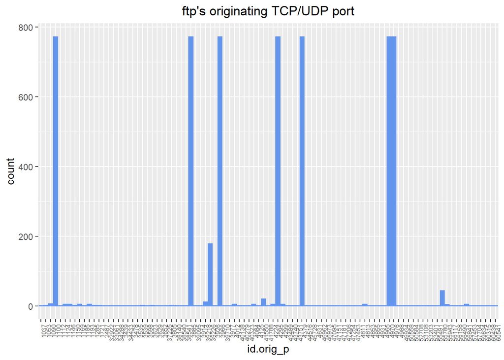

```r
#Frequency distribution histogram
ftpdata$id.orig_p<-as.character(ftpdata$id.orig_p)
ggplot(ftpdata,aes(id.orig_p)) +geom_bar(color="#6495ED",fill="#6495ED") +ggtitle("ftp's originating TCP/UDP port") +theme(axis.text.x = element_text(angle=90, hjust=1, vjust=1,size=6),plot.title=element_text(hjust = 0.5))
```

Ftp has seven commonly used originating ports, and during this period of time have been connected 772 times, but I am not clear about its specific meaning, I think it is worth studying.

## Activity 1.5: Responding endpoint’s TCP/UDP port (or ICMP code)

```r
sort(table(dhcpdata$id.resp_p), decreasing=TRUE)[1:3]
```

```
##   67 <NA> <NA>
## 1502   NA   NA
```

```r
sort(table(ftpdata$id.resp_p), decreasing=TRUE)[1:3]
```

```
##   21 <NA> <NA>
## 5796   NA   NA
```

```r
sort(table(smtpdata$id.resp_p), decreasing=TRUE)[1:3]
```

```
##   25 <NA> <NA>
##  194   NA   NA
```

```r
sort(table(tunneldata$id.resp_p), decreasing=TRUE)[1:3]
```

```
## 3544 <NA> <NA>
##  280   NA   NA
```

All connections have only one responding port.

## Activity 1.6: Originating endpoint’s IP address (AKA ORIG)

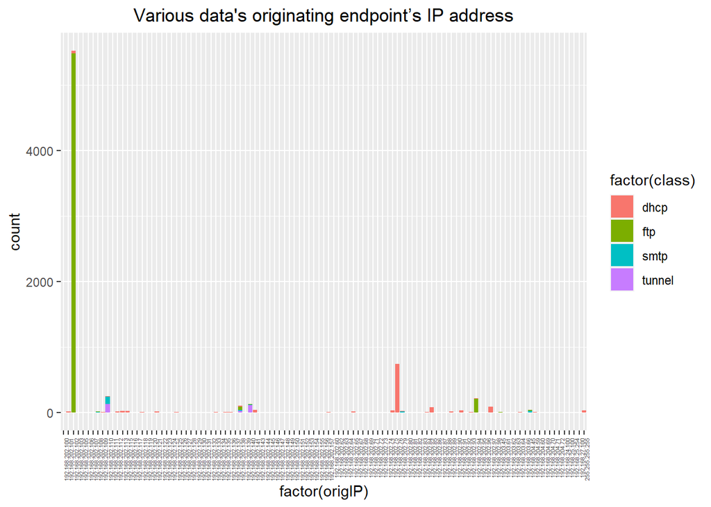

```r
#Create data frame of dhcp's originating IP
number<-c(1:data_count[1])
origIP<-dhcpdata$id.orig_h
class<-rep("dhcp",data_count[1])
dhcporigIP<-data.frame(number,origIP,class)

#Create data frame of ftp's originating IP
number<-c(1:data_count[2])
origIP<-ftpdata$id.orig_h
class<-rep("ftp",data_count[2])
ftporigIP<-data.frame(number,origIP,class)

#Create data frame of smtp's originating IP
number<-c(1:data_count[3])
origIP<-smtpdata$id.orig_h
class<-rep("smtp",data_count[3])
smtporigIP<-data.frame(number,origIP,class)

#Create data frame of tunnel's originating IP
number<-c(1:data_count[4])
origIP<-tunneldata$id.orig_h
class<-rep("tunnel",data_count[4])
tunnelorigIP<-data.frame(number,origIP,class)

#Merge the above data frame
totalorigIP<-rbind(dhcporigIP,ftporigIP,smtporigIP,tunnelorigIP)

#Stacked column chart
ggplot(totalorigIP,aes(factor(origIP),fill=factor(class)))+geom_bar() +ggtitle("Various data's originating endpoint’s IP address") +theme(axis.text.x = element_text(angle=90, hjust=1, vjust=1,size=4),plot.title=element_text(hjust = 0.5))
```

There are a lot of originating endpoint’s IP addresses, some of them only send one type of connection, and some addresses send multiple connections.

Most of ftp and dhcp are gathered on one originating endpoint’s IP address respectively.

## Activity 1.7: Responding endpoint’s IP address (AKA ORIG)

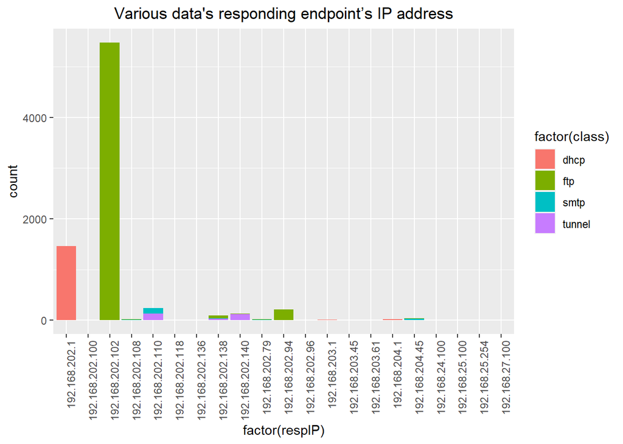

```r
#Create data frame of dhcp's responding IP
number<-c(1:data_count[1])
respIP<-dhcpdata$id.resp_h
class<-rep("dhcp",data_count[1])
dhcprespIP<-data.frame(number,respIP,class)

#Create data frame of ftp's responding IP
number<-c(1:data_count[2])
respIP<-ftpdata$id.orig_h
class<-rep("ftp",data_count[2])
ftprespIP<-data.frame(number,respIP,class)

#Create data frame of smtp's responding IP
number<-c(1:data_count[3])
respIP<-smtpdata$id.orig_h
class<-rep("smtp",data_count[3])
smtprespIP<-data.frame(number,respIP,class)

#Create data frame of tunnel's responding IP
number<-c(1:data_count[4])
respIP<-tunneldata$id.orig_h
class<-rep("tunnel",data_count[4])
tunnelrespIP<-data.frame(number,respIP,class)

#Merge the above data frame
totalrespIP<-rbind(dhcprespIP,ftprespIP,smtprespIP,tunnelrespIP)

#Stacked column chart
ggplot(totalrespIP,aes(factor(respIP),fill=factor(class)))+geom_bar() +ggtitle("Various data's responding endpoint’s IP address") +theme(axis.text.x = element_text(angle=90, hjust=1, vjust=1),plot.title=element_text(hjust = 0.5))
```

There are several responding endpoint’s IP addresses, some of them only receive one type of connection, and some addresses receive multiple connections.

Most of ftp and dhcp are gathered on one responding endpoint’s IP address respectively.

## Activity 2.1: Download and read the data

```r
library(caret)
url <- "http://kdd.ics.uci.edu/databases/kddcup99/kddcup.names"
req <- "D:\\dst\\data\\kddcup.names"
if(file.access(req)){
  download.file(url,req)
}
kddata<-read.csv("D:\\dst\\data\\kddcup.data_10_percent.gz")
kddnames=read.table("D:\\dst\\data\\kddcup.names",sep=":",skip=1,as.is=T)
colnames(kddata)=c(kddnames[,1],"normal")
head(kddata)
```

```
##   duration protocol_type service flag src_bytes dst_bytes land wrong_fragment
## 1        0           tcp    http   SF       239       486    0              0
## 2        0           tcp    http   SF       235      1337    0              0
## 3        0           tcp    http   SF       219      1337    0              0
## 4        0           tcp    http   SF       217      2032    0              0
## 5        0           tcp    http   SF       217      2032    0              0
## 6        0           tcp    http   SF       212      1940    0              0
##   urgent hot num_failed_logins logged_in num_compromised root_shell
## 1      0   0                 0         1               0          0
## 2      0   0                 0         1               0          0
## 3      0   0                 0         1               0          0
## 4      0   0                 0         1               0          0
## 5      0   0                 0         1               0          0
## 6      0   0                 0         1               0          0
##   su_attempted num_root num_file_creations num_shells num_access_files
```

[output cut: 48 more lines]

## Activity 2.2: Preprocess and classify data

Attacks fall into four main categories:

1. DOS: denial-of-service, e.g. syn flood;
2. R2L: unauthorized access from a remote machine, e.g. guessing password;
3. U2R: unauthorized access to local superuser (root) privileges, e.g., various ``buffer overflow’’ attacks;
4. probing: surveillance and other probing, e.g., port scanning.

```r
# Preprocessing the data
kddata$duration = as.numeric(as.character(kddata$duration))
kddata$protocol_type = factor(kddata$protocol_type)
kddata$service = factor(kddata$service)
kddata$flag = factor(kddata$flag)
kddata$src_bytes = as.numeric(as.character(kddata$src_bytes))
kddata$dst_bytes = as.numeric(as.character(kddata$dst_bytes))
kddata$land = factor(kddata$land)
kddata$wrong_fragment = as.numeric(as.character(kddata$wrong_fragment))
kddata$urgent = as.numeric(as.character(kddata$urgent))
kddata$hot = as.numeric(as.character(kddata$hot))
kddata$num_failed_logins = as.numeric(as.character(kddata$num_failed_logins))
kddata$logged_in = factor(kddata$logged_in)
kddata$num_compromised = as.numeric(as.character(kddata$num_compromised))
kddata$root_shell = factor(kddata$root_shell)
kddata$su_attempted = factor(kddata$su_attempted)
kddata$num_root = as.numeric(as.character(kddata$num_root))
kddata$num_file_creations = as.numeric(as.character(kddata$num_file_creations))
kddata$num_shells = as.numeric(as.character(kddata$num_shells))
kddata$num_access_files = as.numeric(as.character(kddata$num_access_files))
# kddata$num_outbound_cmds = as.numeric(as.character(kddata$num_outbound_cmds))
# kddata$is_hot_login = factor(kddata$is_hot_login)
kddata$is_guest_login = factor(kddata$is_guest_login)
kddata$count = as.numeric(as.character(kddata$count))
kddata$srv_count = as.numeric(as.character(kddata$srv_count))
kddata$serror_rate = as.numeric(as.character(kddata$serror_rate))
kddata$srv_serror_rate = as.numeric(as.character(kddata$srv_serror_rate))
kddata$rerror_rate = as.numeric(as.character(kddata$rerror_rate))
kddata$srv_rerror_rate = as.numeric(as.character(kddata$srv_rerror_rate))
kddata$same_srv_rate = as.numeric(as.character(kddata$same_srv_rate))
kddata$diff_srv_rate = as.numeric(as.character(kddata$diff_srv_rate))
kddata$srv_diff_host_rate = as.numeric(as.character(kddata$srv_diff_host_rate))
kddata$dst_host_count = as.numeric(as.character(kddata$dst_host_count))
kddata$dst_host_srv_count = as.numeric(as.character(kddata$dst_host_srv_count))
kddata$dst_host_same_srv_rate = as.numeric(as.character(kddata$dst_host_same_srv_rate))
kddata$dst_host_diff_srv_rate = as.numeric(as.character(kddata$dst_host_diff_srv_rate))
kddata$dst_host_same_src_port_rate = as.numeric(as.character(kddata$dst_host_same_src_port_rate))
kddata$dst_host_srv_diff_host_rate = as.numeric(as.character(kddata$dst_host_srv_diff_host_rate))
kddata$dst_host_serror_rate = as.numeric(as.character(kddata$dst_host_serror_rate))
kddata$dst_host_srv_serror_rate = as.numeric(as.character(kddata$dst_host_srv_serror_rate))
kddata$dst_host_rerror_rate = as.numeric(as.character(kddata$dst_host_rerror_rate))
kddata$dst_host_srv_rerror_rate = as.numeric(as.character(kddata$dst_host_srv_rerror_rate))

# normal preprocess
# The normal is classified into 5 groups
# Subsetting the normal variable into 5 groups.

kddata$normal = as.character(kddata$normal)
kddata$normal[kddata$normal == "ipsweep."] = "probe"
kddata$normal[kddata$normal == "portsweep."] = "probe"
kddata$normal[kddata$normal == "nmap."] = "probe"
kddata$normal[kddata$normal == "satan."] = "probe"
kddata$normal[kddata$normal == "buffer_overflow."] = "u2r"
kddata$normal[kddata$normal == "loadmodule."] = "u2r"
kddata$normal[kddata$normal == "perl."] = "u2r"
kddata$normal[kddata$normal == "rootkit."] = "u2r"
kddata$normal[kddata$normal == "back."] = "dos"
kddata$normal[kddata$normal == "land."] = "dos"
kddata$normal[kddata$normal == "neptune."] = "dos"
kddata$normal[kddata$normal == "pod."] = "dos"
kddata$normal[kddata$normal == "smurf."] = "dos"
kddata$normal[kddata$normal == "teardrop."] = "dos"
kddata$normal[kddata$normal == "ftp_write."] = "r2l"
kddata$normal[kddata$normal == "guess_passwd."] = "r2l"
kddata$normal[kddata$normal == "imap."] = "r2l"
kddata$normal[kddata$normal == "multihop."] = "r2l"
kddata$normal[kddata$normal == "phf."] = "r2l"
kddata$normal[kddata$normal == "spy."] = "r2l"
kddata$normal[kddata$normal == "warezclient."] = "r2l"
kddata$normal[kddata$normal == "warezmaster."] = "r2l"
kddata$normal[kddata$normal == "normal."] = "normal"
kddata$normal = as.factor(kddata$normal)
```

## Activity 2.3: Analyze the influence of each attribute on the intrusion type

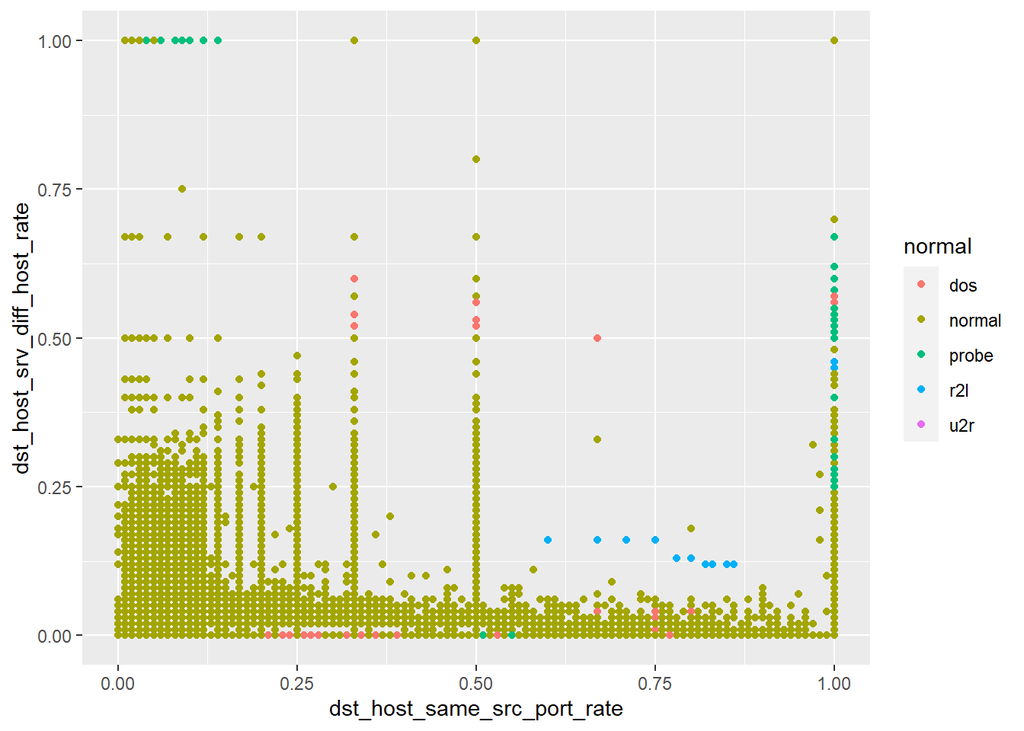

```r
qplot(dst_host_same_src_port_rate,dst_host_srv_diff_host_rate,colour=normal,data=kddata)
```

“dst_host_same_src_port_rate” is a slight predictor.

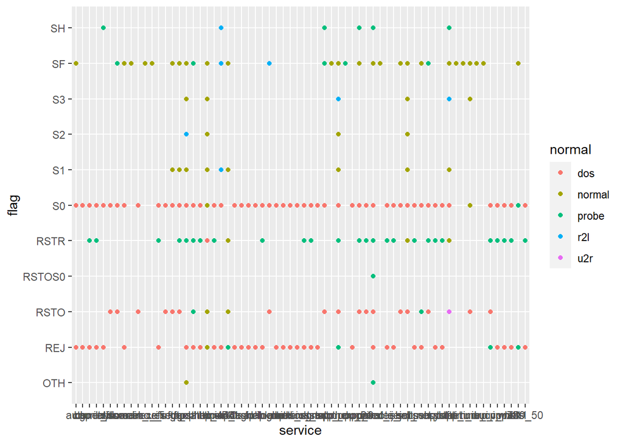

```r
qplot(service,flag,colour=normal,data=kddata)
```

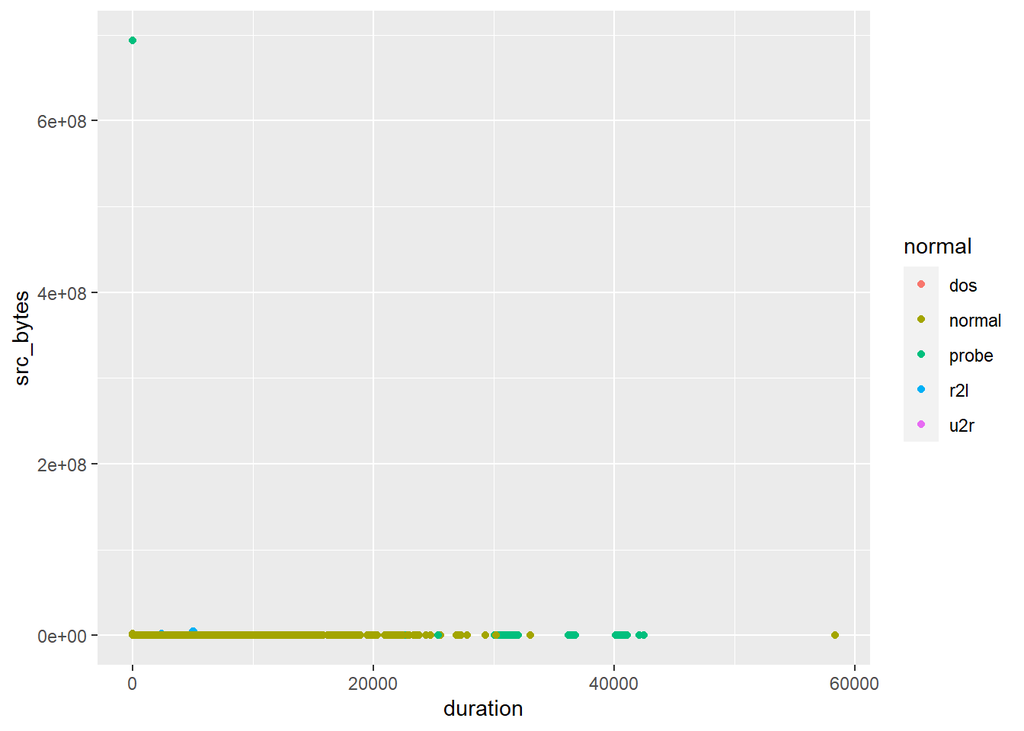

```r
qplot(duration,src_bytes,colour=normal,data=kddata)
```

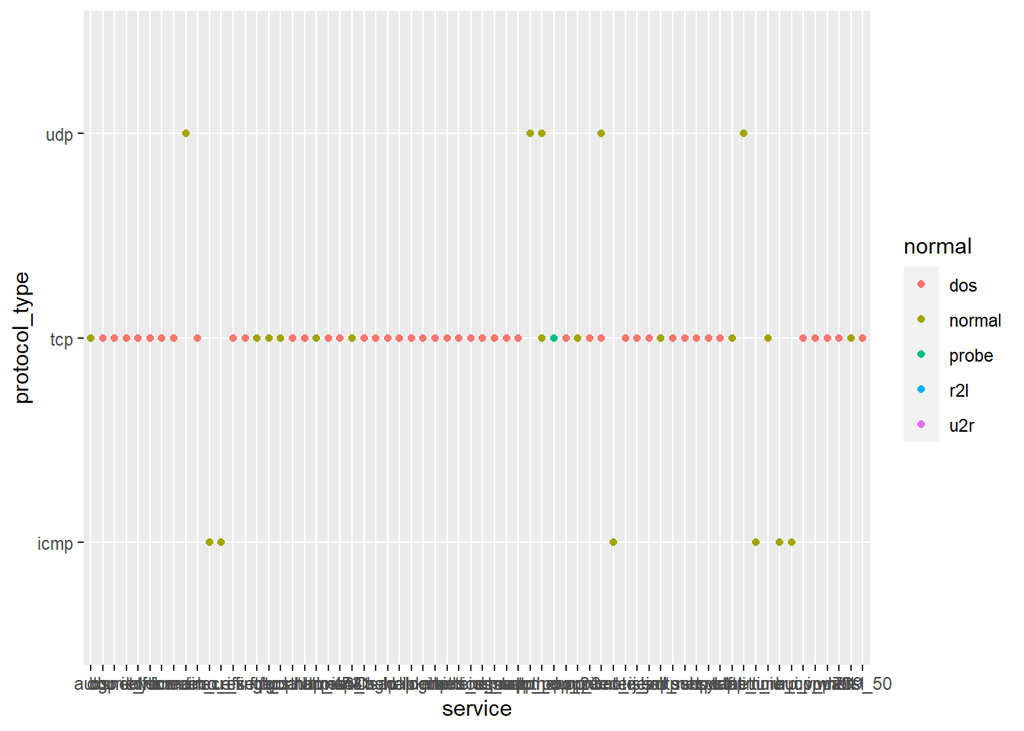

```r
qplot(service,protocol_type,colour=normal,data=kddata)
```

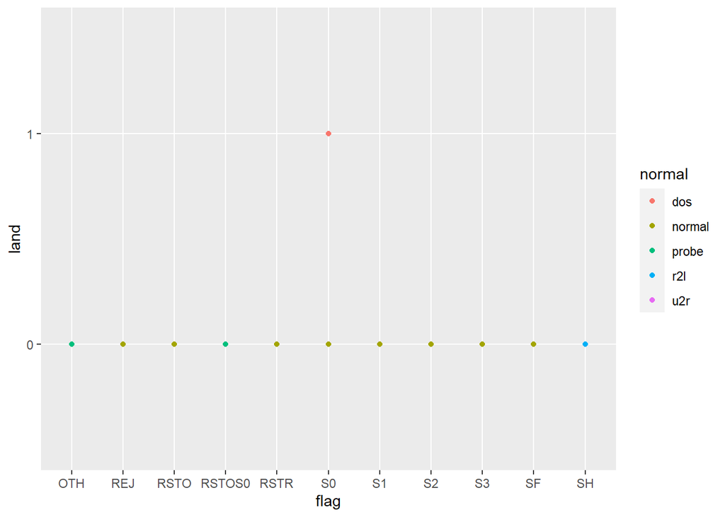

```r
qplot(flag,land,colour=normal,data=kddata)
```

No clear information.

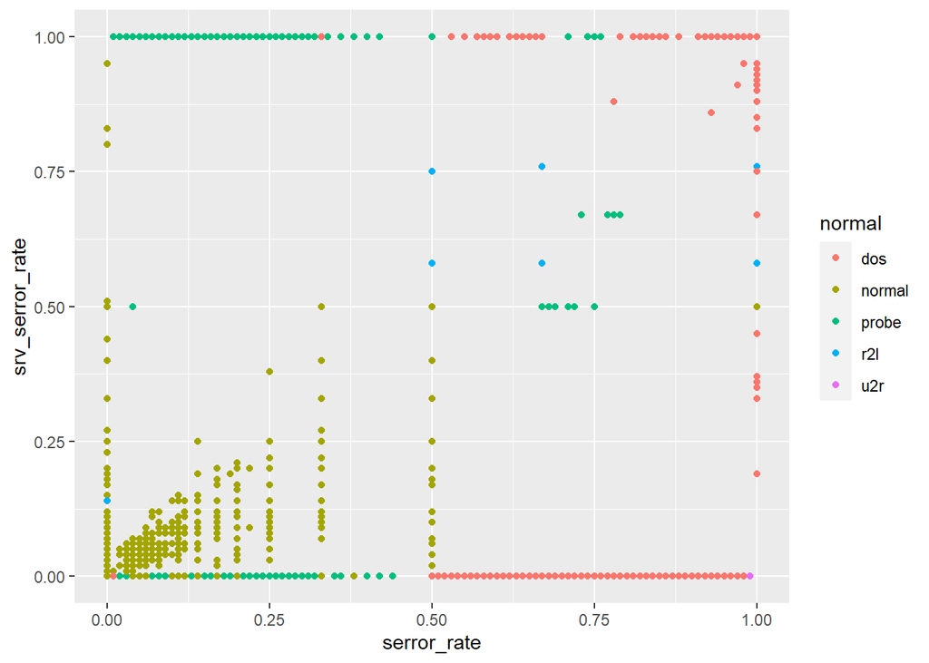

```r
qplot(serror_rate,srv_serror_rate,colour=normal,data=kddata)
```

“serror_rate” and “srv_serror_rate” is two strong predictors, when “serror_rate” > 0.5 and “srv_serror_rate” = 0 or 1, intrusion type is “dos”; when “serror_rate” < 0.5 and “srv_serror_rate” = 0 or 1, intrusion type is “probe”

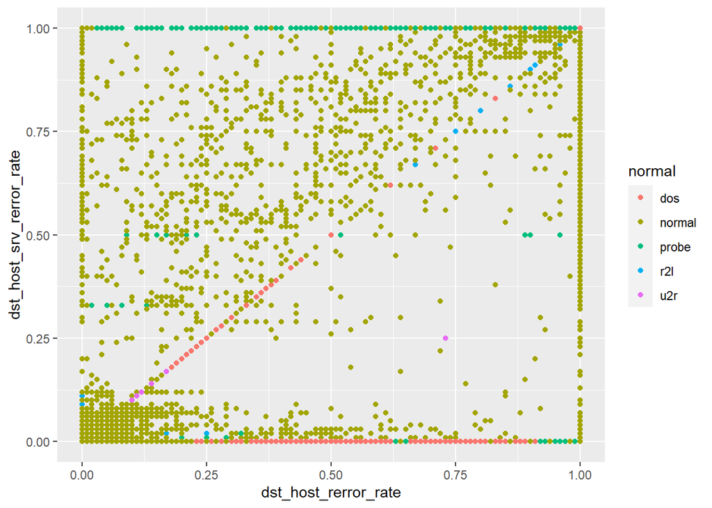

```r
qplot(dst_host_rerror_rate,dst_host_srv_rerror_rate,colour=normal,data=kddata)
```

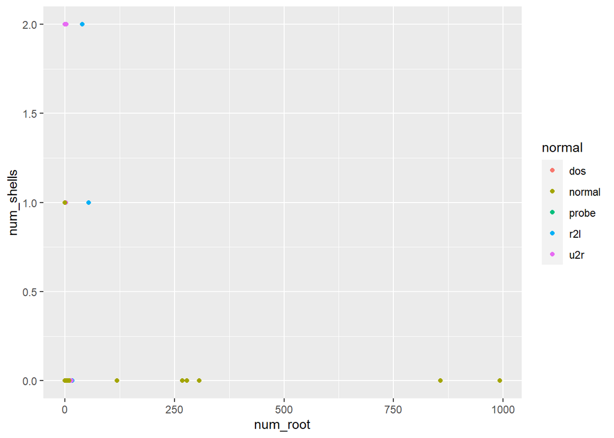

```r
qplot(num_root,num_shells,colour=normal,data=kddata)
```

No clear information.

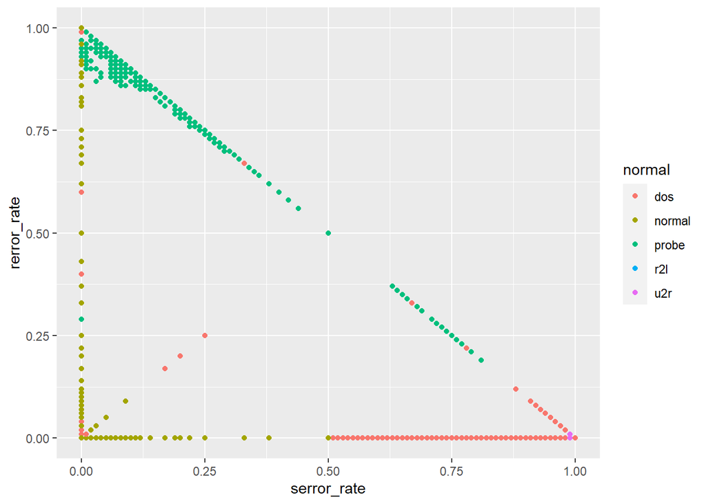

```r
qplot(serror_rate,rerror_rate,colour=normal,data=kddata)
```

“serror_rate” and “rerror_rate” are two strong predictors, when “serror_rate” + “rerror_rate” =1 and “serror_rate” < 0.875, intrusion type is “probe”, but when “serror_rate” > 0.875, intrusion type is “dos”.

## References

http://www.netresec.com/?page=MACCDC MACCDC2012 data source

https://drive.google.com/drive/folders/1qBmJhVqPprD-esGKgtm6VLn_YOpjawJ- MACCDC2012 data source

http://gauss.ececs.uc.edu/Courses/c6055/pdf/bro_log_vars.pdf Network data bro Logs

http://kdd.ics.uci.edu/databases/kddcup99/kddcup99.html KDD Cup 1999 data sourece

https://rstudio-pubs-static.s3.amazonaws.com/196063_b22a7dcd2ec24413b13b280f4865a2c2.html KDD Cup 1999 data analysis